# Project - FMST:Concrete Strength Prediction

##### Outliers. The strategy adopted was to compute the z-scores and remove the data points with z-scores > 3 . The threshold of 3 is a standard value used in such determination.

```python
#calculate z-scores
from scipy import stats
#import scipy.stats as stats
z_scores = np.abs(stats.zscore(df2))
```

```python
#narrow down data set to all columns wit z scores of less than 3
df2 = df2[(z_scores < 3).all(axis=1)]
print ("data frame with no outliers shape", df2.shape)
print ("data frame with no outliers describe", df2.describe)
```

```
data frame with no outliers shape (981, 11)
data frame with no outliers describe <bound method NDFrame.describe of       cement   slag    ash  water  superplastic  coarseagg  fineagg  age  \
0      141.3  212.0    0.0  203.5           0.0      971.8    748.5   28
1      168.9   42.2  124.3  158.3          10.8     1080.8    796.2   14
2      250.0    0.0   95.7  187.4           5.5      956.9    861.2   28
3      266.0  114.0    0.0  228.0           0.0      932.0    670.0   28
4      154.8  183.4    0.0  193.3           9.1     1047.4    696.7   28
...      ...    ...    ...    ...           ...        ...      ...  ...
1023   141.3  212.0    0.0  203.5           0.0      971.8    748.5    7
1024   297.2    0.0  117.5  174.8           9.5     1022.8    753.5    3
1025   135.0    0.0  166.0  180.0          10.0      961.0    805.0   28
1027   276.4  116.0   90.3  179.6           8.9      870.1    768.3   28
1029   540.0    0.0    0.0  173.0           0.0     1125.0    613.0    7

      strength  age_months  strength_category
0        29.89           1                  3
1        23.51           1                  2
2        29.22           1                  3
3        45.85           1                  3
4        18.29           1                  2
...        ...         ...                ...
1023     10.39           1                  1
1024     21.91           1                  2
1025     13.29           1                  1
1027     44.28           1                  3
1029     52.61           1                  3

[981 rows x 11 columns]>
```

```python
#show the relationship between the target and predictor variables
df2.groupby(df2['strength_category']).mean()
```

| strength_category | cement | slag | ash | water | superplastic | coarseagg | fineagg | age | strength | age_months |
| --- | --- | --- | --- | --- | --- | --- | --- | --- | --- | --- |
| 1 | 214.143919 | 57.677703 | 58.233108 | 187.084459 | 3.616892 | 992.331081 | 802.754054 | 9.067568 | 11.967297 | 1.000000 |
| 2 | 244.591429 | 61.341905 | 55.426667 | 183.790000 | 4.315714 | 993.659524 | 787.988095 | 22.214286 | 22.918524 | 1.128571 |
| 3 | 303.626966 | 80.736918 | 56.843339 | 178.236276 | 7.440128 | 964.166774 | 765.609631 | 47.751204 | 45.007352 | 1.842697 |

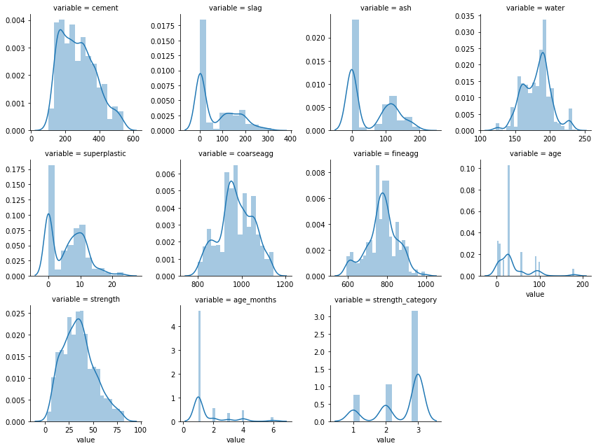

```python
num = [f for f in df2.columns if df2.dtypes[f] != 'object']
nd = pd.melt(df2, value_vars = num)
n1 = sns.FacetGrid (nd, col='variable', col_wrap=4, sharex=False, sharey = False)
n1 = n1.map(sns.distplot, 'value')
n1
```

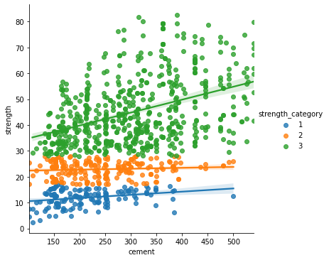

```python
sns.lmplot(x='cement',y='strength',data= df2,hue= 'strength_category')
```

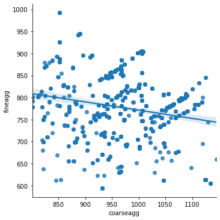

```python
sns.lmplot(x='coarseagg',y='fineagg',data = df2)
```

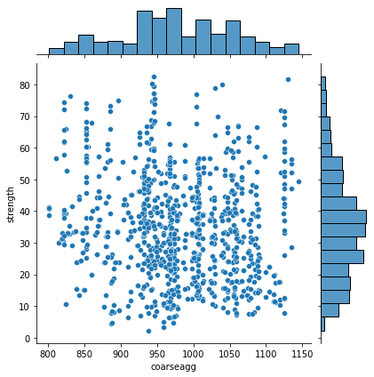

```python
sns.jointplot(df2['coarseagg'],df2['strength'])
```

### 3. Feature Engineering techniques(10 marks)

#### 1. Identify opportunities (if any) to extract new features from existing features, drop a feature(if required) Hint: Feature Extraction, for example, consider a dataset with two features length and breadth. From this, we can extract a new feature Area which would be length * breadth.

ref:

1. https://www.sciencedirect.com/science/article/abs/pii/S0950061819320719
2. https://www.scipedia.com/public/Silva_et_al_2020a

```python
df2 = df.copy(deep=True)
def feature1(data2):
   return (data2["ash"]*data2["cement"])
df2["ash_cement"] = df2.apply(lambda df2:feature1(df2) ,axis =1)
```

```python
df2 = df.copy(deep=True)
def feature1(data2):
   return (data2["slag"]*data2["cement"])
df2["slag_cement"] = df2.apply(lambda df2:feature1(df2) ,axis =1)
```

```python
def feature2(data2):
   return (data2["fineagg"]*data2["water"])

df2["fineagg_water"] = df2.apply(lambda df2:feature2(df2) ,axis =1)
```

```python
df2.head(10)
```

|  | cement | slag | ash | water | superplastic | coarseagg | fineagg | age | strength | age_months | slag_cement | fineagg_water |
| --- | --- | --- | --- | --- | --- | --- | --- | --- | --- | --- | --- | --- |
| 0 | 141.3 | 212.0 | 0.0 | 203.5 | 0.0 | 971.8 | 748.5 | 28 | 29.89 | 1 | 29955.60 | 152319.75 |
| 1 | 168.9 | 42.2 | 124.3 | 158.3 | 10.8 | 1080.8 | 796.2 | 14 | 23.51 | 1 | 7127.58 | 126038.46 |
| 2 | 250.0 | 0.0 | 95.7 | 187.4 | 5.5 | 956.9 | 861.2 | 28 | 29.22 | 1 | 0.00 | 161388.88 |
| 3 | 266.0 | 114.0 | 0.0 | 228.0 | 0.0 | 932.0 | 670.0 | 28 | 45.85 | 1 | 30324.00 | 152760.00 |
| 4 | 154.8 | 183.4 | 0.0 | 193.3 | 9.1 | 1047.4 | 696.7 | 28 | 18.29 | 1 | 28390.32 | 134672.11 |
| 5 | 255.0 | 0.0 | 0.0 | 192.0 | 0.0 | 889.8 | 945.0 | 90 | 21.86 | 3 | 0.00 | 181440.00 |
| 6 | 166.8 | 250.2 | 0.0 | 203.5 | 0.0 | 975.6 | 692.6 | 7 | 15.75 | 1 | 41733.36 | 140944.10 |
| 7 | 251.4 | 0.0 | 118.3 | 188.5 | 6.4 | 1028.4 | 757.7 | 56 | 36.64 | 2 | 0.00 | 142826.45 |
| 8 | 296.0 | 0.0 | 0.0 | 192.0 | 0.0 | 1085.0 | 765.0 | 28 | 21.65 | 1 | 0.00 | 146880.00 |
| 9 | 155.0 | 184.0 | 143.0 | 194.0 | 9.0 | 880.0 | 699.0 | 28 | 28.99 | 1 | 28520.00 | 135606.00 |

#### 2. Get the data model ready and do a train test split.

```python
#separating dependent and independent variables
y = df['strength']
X = df.drop(columns = {'strength'})
```

```python
#X_train, X_test, y_train, y_test = train_test_split(X, y, test_size = .30, random_state=0)
#Always a good practice to split the dataset into 3 sets
X_train, X_test, y_train, y_test = train_test_split(X, y, test_size = .30, random_state= 22)
X_train, X_val, y_train, y_val = train_test_split(X_train, y_train, test_size=0.25, random_state=22)
```

#### 3. Decide on the complexity of the model, should it be a simple linear model in terms of parameters or would a quadratic or higher degree.

###### In this project we decided to use a multivariate polynomial regression model rather than the simpler linear regression model. The multivariate regression model uses the nth degree polynomials of the input variables to predict the output variables. In ths project we used a degree of 5.

```python
from sklearn.metrics import mean_squared_error
from sklearn.preprocessing import PolynomialFeatures
from sklearn.pipeline import make_pipeline

degree=5
polyreg=make_pipeline(PolynomialFeatures(degree),LinearRegression())
polyreg.fit(X,y)
```

```
Pipeline(memory=None,
         steps=[('polynomialfeatures',
                 PolynomialFeatures(degree=5, include_bias=True,
                                    interaction_only=False, order='C')),
                ('linearregression',
                 LinearRegression(copy_X=True, fit_intercept=True, n_jobs=None,
                                  normalize=False))],
         verbose=False)
```

```python
#resultsDf = resultsDf[['Method', 'accuracy']]
y_predict_polyreg = polyreg.predict(X_test)
print(y_predict_polyreg)
print(polyreg.score(X_train,y_train))
```

[output not shown]

```python
def rmse(y_test,y_pred):
      return np.sqrt(mean_squared_error(y_test,y_pred))
```

```python
# run prediction on training set to get an idea of how well it does
print("rmse score ", rmse(y_test, y_predict_polyreg))
```

```
rmse score  0.5327133818873359
```

```python
#Store the accuracy results for each model in a dataframe for final comparison
acc_LR = polyreg.score(X_test,y_test)
resultsDf = pd.DataFrame({'Method':['Polynomial Regression'], 'accuracy': acc_LR})
resultsDf = resultsDf[['Method', 'accuracy']]
resultsDf
```

|  | Method | accuracy |
| --- | --- | --- |
| 0 | Polynomial Regression | 0.99908 |

###### In this project we also decided to explore the use of Kernalized Regression Methods. Kernalized regression methods utilize two mathematical concepts applied in tandem – a transformation of the predictor variables and the pairing of the new predictors with a regression method.

```python
from sklearn.kernel_ridge import KernelRidge
kridge = KernelRidge(alpha=1.0)
kridge.fit(X, y)
```

```
KernelRidge(alpha=1.0, coef0=1, degree=3, gamma=None, kernel='linear',
            kernel_params=None)
```

```python
print(kridge.score(X_train,y_train))
```

```
0.6999706052045793
```

```python
y_predict_kridge = kridge.predict(X_test)
acc_RF = kridge.score(X_test,y_test)
tempResultsDf = pd.DataFrame({'Method':['KernelRidge'], 'accuracy': acc_RF})
resultsDf = pd.concat([resultsDf, tempResultsDf])
resultsDf = resultsDf[['Method', 'accuracy']]
resultsDf
```

|  | Method | accuracy |
| --- | --- | --- |
| 0 | Polynomial Regression | 0.999080 |
| 0 | KernelRidge | 0.711418 |

# Creating the Model and Tuning It:

### 1. Algorithms that you think will be suitable for this project. Use Kfold Cross-Validation to

Evaluate model performance. Use appropriate metrics and make a DataFrame to compare models w.r.t their metrics. (at least 3 algorithms, one bagging and one boosting based algorithms have to be there). (15 marks)

###### For evaluating model performance we considered 4 algorithms in conjunction with Kfold cross-validation method. The algorithms considered are: (1)Support Vector Regressor (SVR), (2) Bagging Regressor, (3) Gradient Boosting Regressor , and (4)Random Forest Regressor

-

```python
from sklearn.model_selection import KFold
from sklearn.preprocessing import MinMaxScaler
from sklearn.svm import SVR
scaler = MinMaxScaler(feature_range=(0, 1))
X = scaler.fit_transform(X)
scores = []
best_svr = SVR(kernel='rbf')
cv = KFold(n_splits=10, random_state=42, shuffle=False)
for train_index, test_index in cv.split(X):
    print("Train Index: ", train_index, "\n")
    print("Test Index: ", test_index)

    X_train, X_test, y_train, y_test = X[train_index], X[test_index], y[train_index], y[test_index]
    best_svr.fit(X_train, y_train)
    scores.append(best_svr.score(X_test, y_test))
```

[output not shown]

[output cut: 712 more lines]

```python
acc_RF = np.mean(scores)
tempResultsDf = pd.DataFrame({'Method':['SVR'], 'accuracy': [acc_RF]})
resultsDf = pd.concat([resultsDf, tempResultsDf])
resultsDf = resultsDf[['Method', 'accuracy']]
resultsDf
```

|  | Method | accuracy |
| --- | --- | --- |
| 0 | Polynomial Regression | 0.999080 |
| 0 | KernelRidge | 0.711418 |
| 0 | SVR | 0.626296 |

```python
from sklearn.model_selection import KFold
from sklearn.preprocessing import MinMaxScaler
from sklearn.ensemble import BaggingRegressor
scaler = MinMaxScaler(feature_range=(0, 1))
X = scaler.fit_transform(X)
scores = []
best_bag = BaggingRegressor(base_estimator=SVR(),n_estimators=10, random_state=0).fit(X, y)
cv = KFold(n_splits=10, random_state=42, shuffle=False)
for train_index, test_index in cv.split(X):
    print("Train Index: ", train_index, "\n")
    print("Test Index: ", test_index)

    X_train, X_test, y_train, y_test = X[train_index], X[test_index], y[train_index], y[test_index]
    best_bag.fit(X_train, y_train)
    scores.append(best_bag.score(X_test, y_test))
```

[output not shown]

[output cut: 712 more lines]

```python
print(np.mean(scores))
```

```
0.6227517944350313
```

```python
acc_RF = best_bag.score(X_test,y_test)
tempResultsDf = pd.DataFrame({'Method':['BaggingRegressor'], 'accuracy': [acc_RF]})
resultsDf = pd.concat([resultsDf, tempResultsDf])
resultsDf = resultsDf[['Method', 'accuracy']]
resultsDf
```

|  | Method | accuracy |
| --- | --- | --- |
| 0 | Polynomial Regression | 0.999080 |
| 0 | KernelRidge | 0.711418 |
| 0 | SVR | 0.626296 |
| 0 | BaggingRegressor | 0.592210 |

```python
from sklearn.model_selection import KFold
from sklearn.preprocessing import MinMaxScaler
from sklearn.ensemble import GradientBoostingRegressor
scaler = MinMaxScaler(feature_range=(0, 1))
X = scaler.fit_transform(X)
scores = []
best_boost = GradientBoostingRegressor(n_estimators=100, learning_rate=0.1,max_depth=1, random_state=0, loss='ls').fit(X_train, y_train)
cv = KFold(n_splits=10, random_state=42, shuffle=False)
for train_index, test_index in cv.split(X):
    print("Train Index: ", train_index, "\n")
    print("Test Index: ", test_index)

    X_train, X_test, y_train, y_test = X[train_index], X[test_index], y[train_index], y[test_index]
    best_boost.fit(X_train, y_train)
    scores.append(best_boost.score(X_test, y_test))
```

[output not shown]

[output cut: 712 more lines]

```python
print(np.mean(scores))
```

```
0.8023795379445655
```

```python
acc_RF = best_boost.score(X_test,y_test)
tempResultsDf = pd.DataFrame({'Method':['GradientBoostingRegressor'], 'accuracy': [acc_RF]})
resultsDf = pd.concat([resultsDf, tempResultsDf])
resultsDf = resultsDf[['Method', 'accuracy']]
resultsDf
```

|  | Method | accuracy |
| --- | --- | --- |
| 0 | Polynomial Regression | 0.999080 |
| 0 | KernelRidge | 0.711418 |
| 0 | SVR | 0.626296 |
| 0 | BaggingRegressor | 0.592210 |
| 0 | GradientBoostingRegressor | 0.797501 |

```python
from sklearn.model_selection import KFold
from sklearn.preprocessing import MinMaxScaler
from sklearn.ensemble import RandomForestRegressor
scaler = MinMaxScaler(feature_range=(0, 1))
X = scaler.fit_transform(X)
scores = []
best_forest = RandomForestRegressor(max_depth=8, random_state=0)
cv = KFold(n_splits=10, random_state=42, shuffle=False)
for train_index, test_index in cv.split(X):
    print("Train Index: ", train_index, "\n")
    print("Test Index: ", test_index)

    X_train, X_test, y_train, y_test = X[train_index], X[test_index], y[train_index], y[test_index]
    best_forest.fit(X_train, y_train)
    scores.append(best_forest.score(X_test, y_test))
```

[output not shown]

[output cut: 712 more lines]

```python
acc_RF = best_forest.score(X_test,y_test)
tempResultsDf = pd.DataFrame({'Method':['RandomForestRegressor'], 'accuracy': [acc_RF]})
resultsDf = pd.concat([resultsDf, tempResultsDf])
resultsDf = resultsDf[['Method', 'accuracy']]
resultsDf
```

|  | Method | accuracy |
| --- | --- | --- |
| 0 | Polynomial Regression | 0.999080 |
| 0 | KernelRidge | 0.711418 |
| 0 | SVR | 0.626296 |
| 0 | BaggingRegressor | 0.592210 |
| 0 | GradientBoostingRegressor | 0.797501 |
| 0 | RandomForestRegressor | 0.908963 |